# Mania_Modelling

by_Jasmin_Doenicke

Step 6

Based on the “05_model_comparison.pdf” results, I have picked the best model! It’s the linear 4-class negetive binomial model. This section of the analysis is performing latent class analysis (LCA) result integration, data merging, and visualization. Let’s begin!

# STARTER Code

```r
knitr::opts_chunk$set(error = TRUE)
```

```r
#libraries
library(tidyverse)
library(MplusAutomation)
library(vtable)
library(flextable)
```

```r
setwd("E:")

#load data
load(file='E:/data/GBI_demographics.rdata')

#set theme
theme_set(theme_bw())
```

```r
#read input for ids
data_csv<-read.csv('E:/code/MPLUS/data_headers.csv', header=T)
```

# Load Mplus Output

```r
model_L4<-readModels('E:/code/MPLUS/neg_binomial/03_linear_4class.out',
what=c("savedata"))$savedata

table(model_L4$C) # check class distribution
```

```
##
##    1    2    3    4
##  575 1631 3227 5201
```

The class distribution looks well-structured! Class 1, the smallest group, [exhibits the highest mania symptoms*], with classes getting progressively larger, [and having progressively fewer symptoms]. Given this pattern, using the largest class (Class 4) with no symptoms as the reference category is the most logical choice for comparison.

*Note: We do not see that the smallest class has the lowest symptoms in this table, this can be viewed further below.

```r
# reorder from smallest to biggest - use if necessary (not the case now)
#model_L4<-model_L4 %>% mutate(C=case_when(C==1~1, #means 'when class_l=1, change it to …'.
#                                            C==2~2,#means 'when class_l=2, change it to …'.
#                                            C==3~3,
#                                            C==4~4))

#merge with id data
merge_csv<-cbind(data_csv,model_L4)
merge_csv<-merge_csv %>% rename(class=C) %>% select(src_subject_id,class)
merge<-inner_join(GBI_demographics,merge_csv)
```

# Plotting

Let’s have a look at the best model to fit our data! Linear 4-class negative-binomial model!

First, plot all classes with 95% confidence intervals.

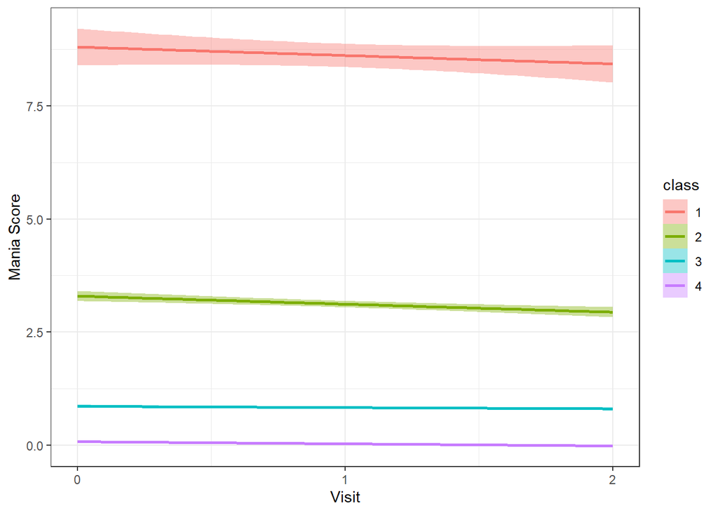

```r
merge %>%
  mutate(class=factor(class)) %>%
  filter(!c(visit=="4"| visit=="3")) %>%
  ggplot(aes(y=pgbi_p_ss_score,x=visit,color=class,fill=class))+
  geom_smooth(method="lm",formula=y ~ poly(x, 1),aes(group=class))+
  scale_x_continuous(breaks = scales::breaks_width(1))+
  xlab("Visit")+
  ylab("Mania Score")
```

Next, plot all classes with individual subject lines.

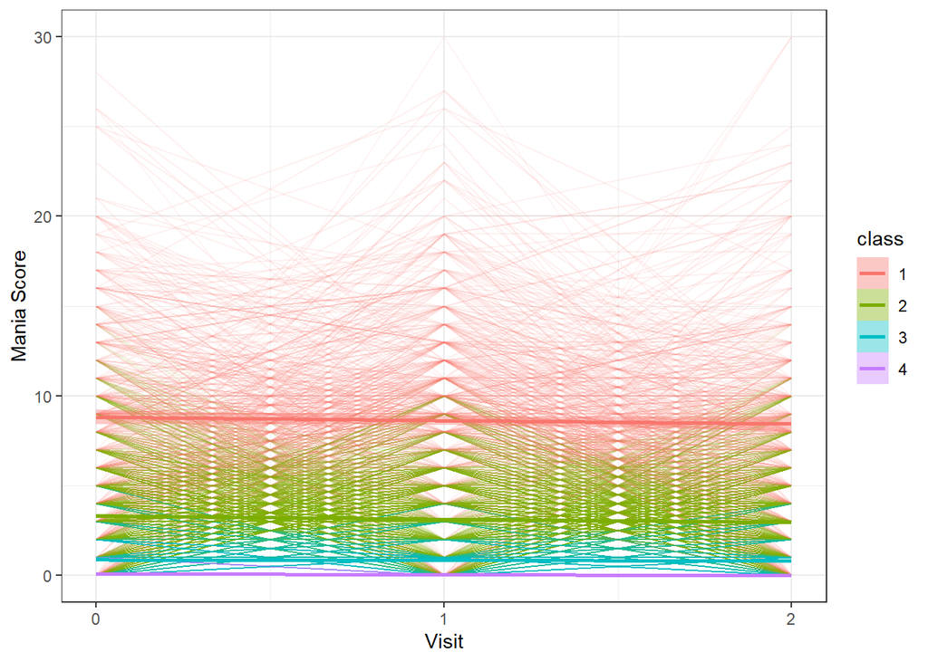

```r
merge %>%
  mutate(class=factor(class)) %>%
    filter(!c(visit=="3"|visit=="4")) %>%
    ggplot(aes(y=pgbi_p_ss_score,x=visit,color=class,fill=class))+
  #geom_point()+
  geom_line(aes(group=src_subject_id),alpha=0.1)+
  geom_smooth(method="lm",formula=y ~ poly(x, 1), # quadratic: (x,2); linear: (x,1)
              aes(group=class))+
                   scale_x_continuous(breaks = scales::breaks_width(1))+
                    xlab("Visit")+
                    ylab("Mania Score")
```

Plot individual subject lines in class 1 (smallest class, highest symptoms).

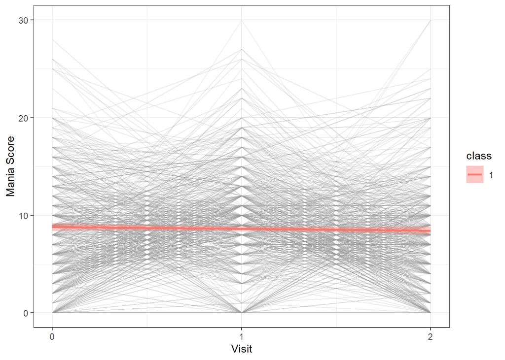

```r
merge %>%
  mutate(class=factor(class)) %>%
  filter(!c(visit=="3"|visit=="4")) %>%
  filter(class=='1') %>%
  ggplot(aes(y=pgbi_p_ss_score,x=visit,color=class,fill=class))+
  geom_line(aes(group=src_subject_id),alpha=0.2,color='grey60')+
  geom_smooth(method="lm",formula=y ~ poly(x, 1), # quadratic: (x,2); linear: (x,1)
              aes(group=class))+
                scale_x_continuous(breaks = scales::breaks_width(1))+
                xlab("Visit")+
                ylab("Mania Score")+
                ylim(0,30)
```

Plot individual subject lines in class 2 (second-smallest class, moderate symptoms).

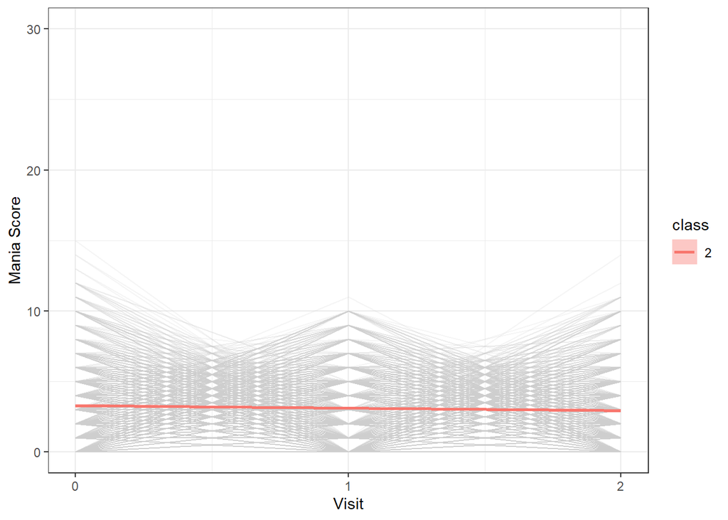

```r
merge %>%
  mutate(class=factor(class)) %>%
    filter(!c(visit=="3"|visit=="4")) %>%
    filter(class=='2') %>%                # Change class here (ex. 2)
  ggplot(aes(y=pgbi_p_ss_score,x=visit,color=class,fill=class))+
  #geom_point()+
  geom_line(aes(group=src_subject_id),alpha=0.2,color='grey80')+
  geom_smooth(method="lm",formula=y ~ poly(x, 1), # quadratic: (x,2); linear: (x,1)
              aes(group=class))+
                scale_x_continuous(breaks = scales::breaks_width(1))+
                xlab("Visit")+
                ylab("Mania Score")+
                ylim(0,30)
```

Plot individual subject lines in class 3 (second-biggest class, low symptoms).

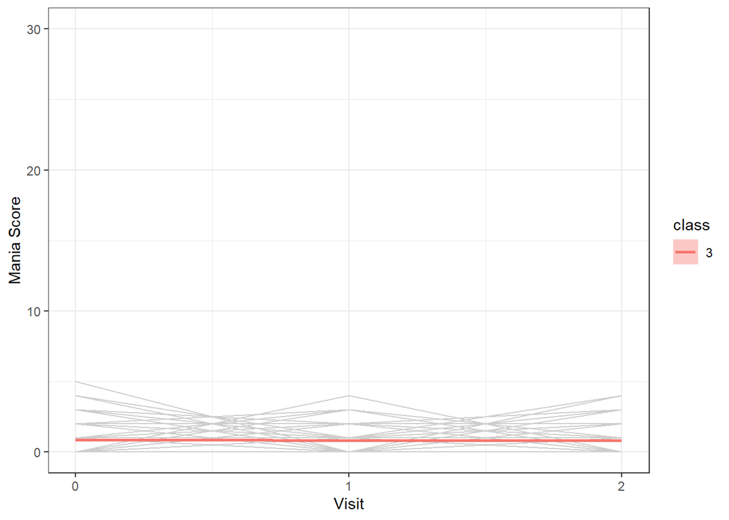

```r
merge %>%
  mutate(class=factor(class)) %>%
    filter(!c(visit=="3"|visit=="4")) %>%
    filter(class=='3') %>%                # Change class here (ex. 2)
  ggplot(aes(y=pgbi_p_ss_score,x=visit,color=class,fill=class))+
  #geom_point()+
  geom_line(aes(group=src_subject_id),alpha=0.2,color='grey80')+
  geom_smooth(method="lm",formula=y ~ poly(x, 1), # quadratic: (x,2); linear: (x,1)
              aes(group=class))+
                scale_x_continuous(breaks = scales::breaks_width(1))+
                xlab("Visit")+
                ylab("Mania Score")+
                ylim(0,30)
```

Plot individual subject lines in class 4 (biggest class, minimal/ no symptoms).

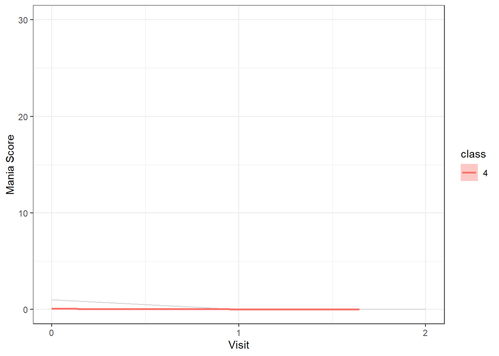

```r
merge %>%
  mutate(class=factor(class)) %>%
    filter(!c(visit=="3"|visit=="4")) %>%
    filter(class=='4') %>%                # Change class here (ex. 2)
  ggplot(aes(y=pgbi_p_ss_score,x=visit,color=class,fill=class))+
  #geom_point()+
  geom_line(aes(group=src_subject_id),alpha=0.2,color='grey80')+
  geom_smooth(method="lm",formula=y ~ poly(x, 1), # quadratic: (x,2); linear: (x,1)
              aes(group=class))+
                scale_x_continuous(breaks = scales::breaks_width(1))+
                xlab("Visit")+
                ylab("Mania Score")+
                ylim(0,30)
```

# Summary Table

```r
library(dplyr)
library(flextable)
library(officer)
```

```r
# Ensure merge0 is not empty before proceeding
if (nrow(merge) > 0) {
  merge0 <- merge %>% filter(visit == 0)

  # Save as CSV with explicit path
  sumtable(merge0,
           vars = c("demo_sex_v2", "interview_age", "race", "ethnicity"),
           group = "class", group.test = TRUE,
           out = "csv", file = "E:/summary_stats_table.csv"
  )

  # Prepare data for the table
  my_data <- merge0 %>% select(demo_sex_v2, interview_age, race, ethnicity, class)

  # Summarize before creating flextable (prevents crashes)
  grouped_data <- my_data %>%
    group_by(class) %>%
    summarise(
      demo_sex_v2 = paste(unique(demo_sex_v2), collapse = ", "),
      interview_age = round(mean(interview_age, na.rm = TRUE), 1),
      race = paste(unique(race), collapse = ", "),
      ethnicity = paste(unique(ethnicity), collapse = ", ")
    )

  # Convert to flextable
  my_table <- flextable(grouped_data)

  # Create a Word document and add the table
  doc <- read_docx() %>%
    body_add_flextable(my_table)

  # Save Word document safely (use valid path)
  doc_path <- "E:/demographics_table.docx"
  if (file.access(dirname(doc_path), 2) == 0) {  # Check write permission
    print(doc, target = doc_path)
  } else {
    print(doc, target = "demographics_table.docx")  # Save in current directory if E:/ is restricted
  }

} else {
  warning("merge0 is empty. Skipping table generation.")
}
```

# Plots

## Demographics

Let’s plot N of individuals in each class. We can see below that Class 1 is the smallest, and the classes get progressively bigger.

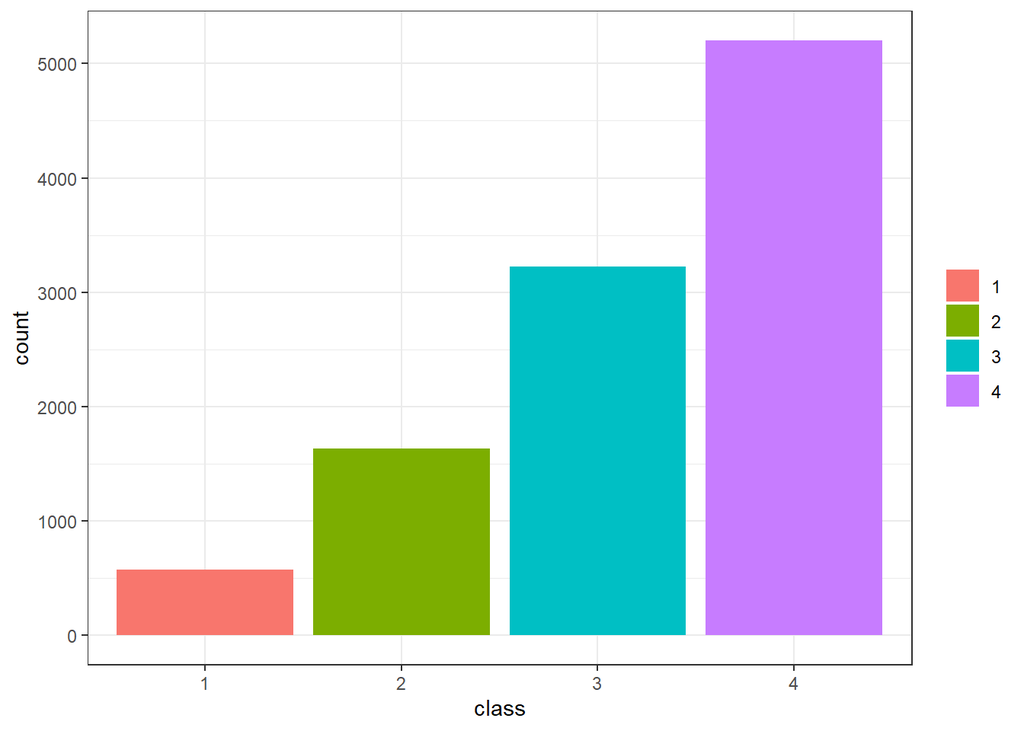

```r
merge0 %>%
  mutate(class=as.factor(class)) %>%
  ggplot(aes(x=class,fill=class))+
  geom_bar()+
  theme(legend.title = element_blank())
```

## Sex-Proportions

Gender distribution shows that males (1) are more prevalent in the ‘High Mania’ class, while females (2) are increasingly represented in the lower mania classes.

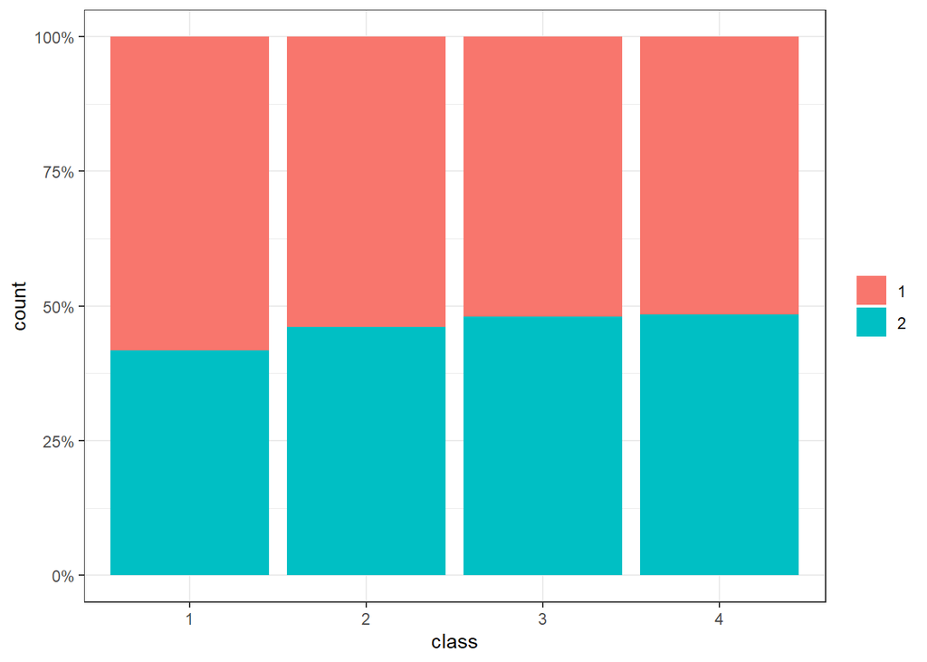

```r
merge0 %>%
  mutate(class=as.factor(class)) %>%
  group_by(class,demo_sex_v2) %>%
  ggplot(aes(x=class,fill=class))+
  geom_bar(position="fill",aes(fill=demo_sex_v2))+
  scale_y_continuous(labels=scales::percent)+
  theme(legend.title = element_blank())
```

## Ethnicity Proportions

Individuals of Hispanic ethnicity are more prevalent in the ‘High Mania’ class, with representation decreasing progressively in the lower mania classes.

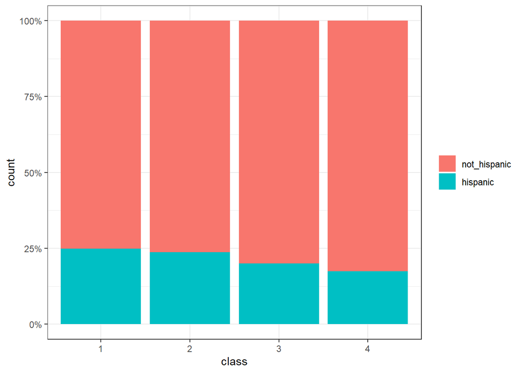

```r
merge0 %>%
  filter(!is.na(ethnicity)) %>%
  mutate(class=as.factor(class)) %>%
  ggplot(aes(x=class,fill=class))+
  geom_bar(position="fill",aes(fill=ethnicity))+
  scale_y_continuous(labels=scales::percent)+
  theme(legend.title = element_blank())
```

## Race proportions

Black/African American and Other/Multiple racial groups have higher representation in the ‘High Mania’ class (Class 1), while White and Asian individuals are more prevalent in the ‘Minimal/ No Symptoms’ class (Class 4).

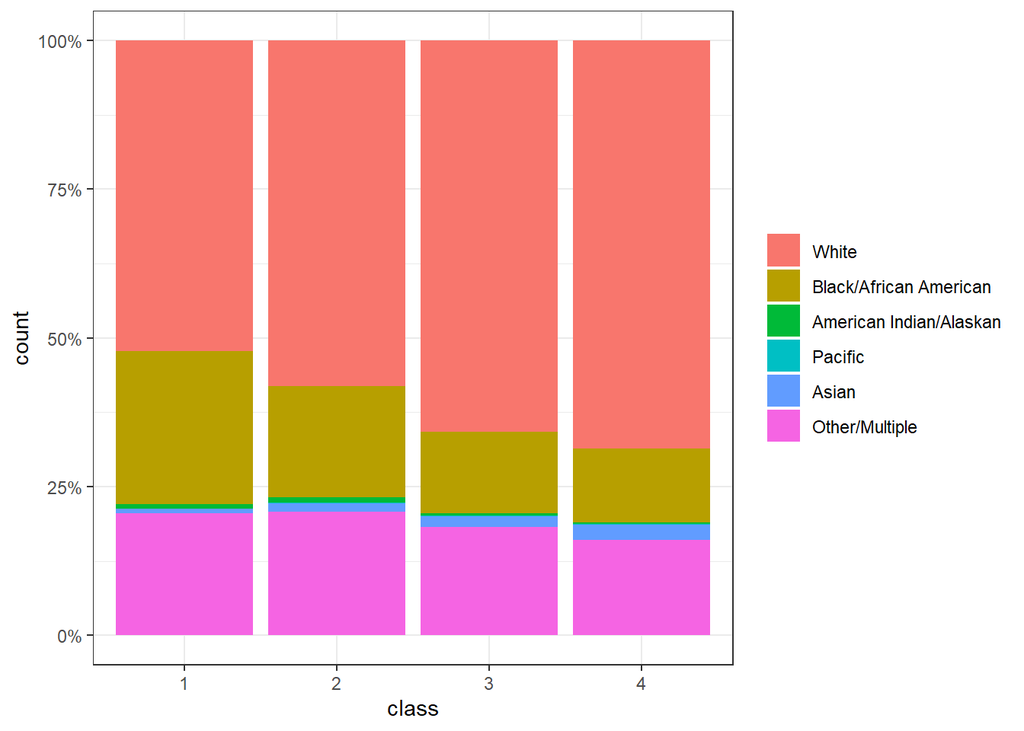

```r
merge0 %>%
  filter(!is.na(race)) %>%
  mutate(class=as.factor(class)) %>%
  ggplot(aes(x=class,fill=class))+
  geom_bar(position="fill",aes(fill=race))+
  scale_y_continuous(labels=scales::percent)+
  theme(legend.title = element_blank())
```

Variability within Classes

There is quite a big range in each class.

The highest mania class goes all the way from 0-30, and spans the entire range of the PGBI-10-M

```r
class1 = merge %>% filter(class==1)
table(class1$pgbi_p_ss_score)
```

```
##
##   0   1   2   3   4   5   6   7   8   9  10  11  12  13  14  15  16  17  18  19
## 171  64  79  85 122 121 119 133 148 147 158 106  93  77  64  49  44  35  25  21
##  20  21  22  23  24  25  26  27  28  30
##  23   6   9   7   3   5   5   2   1   4
```

The moderate mania class has scores ranging from 0-23.

```r
class2 = merge %>% filter(class==2)
table(class2$pgbi_p_ss_score)
```

```
##
##    0    1    2    3    4    5    6    7    8    9   10   11   12   13   14   15
## 1084  754  923  793  641  454  352  212  134   82   87   31   13    3    7    1
##   16   18   19   23
##    1    1    1    1
```

The low mania class has scores ranging from 0-18.

```r
class3 = merge %>% filter(class==3)
table(class3$pgbi_p_ss_score)
```

```
##
##    0    1    2    3    4    5    6    7    8    9   10   11   13   15   18
## 5535 3151 1489  588  196   37   11    5    5    6    4    1    2    1    1
```

The minimal/no symptoms mania class has scores ranging from 0-13.

```r
class4 = merge %>% filter(class==4)
table(class4$pgbi_p_ss_score)
```

```
##
##     0     1     2     3     4     5     6     7     8     9    10    11    12
## 17133   640    55    24    14     7     7     4     4     1     2     2     3
##    13
##     2
```